## Project Title: Predictive Road and Pavement Analytics

## This project aimed to analyze pavement condition data combined with weather and traffic characteristics to predict performance metrics, identify patterns, perform clustering, and model customer review sentiments using machine learning.

Dhanushi Panga Phani Satya Sai Pamarthi Raja Ruthvik Shetty Suraj Bharadwaj Mandava Venkata Yatish Chandra Nalla

## 1. Data Loading

Loaded multiple datasets: pavement experiment sections, traffic trends, weather sensor data, SHRP metadata, and detailed section info. Used pandas to read and inspect data files. Purpose: Gathered all relevant information across domains (pavement, weather, traffic).

```python
import pandas as pd
import numpy as np

exp_section = pd.read_csv('/Users/dhanushivijay/Downloads/EXPERIMENT_SECTION.csv')
exp_section_1 = pd.read_csv('/Users/dhanushivijay/Downloads/EXPERIMENT_SECTION_1 (4).csv')
traffic_data = pd.read_csv('/Users/dhanushivijay/Downloads/TRF_TREND (1).csv')
traffic_trend_1 = pd.read_csv('/Users/dhanushivijay/Downloads/TRF_TREND_1 (1).csv')
weather_temp = pd.read_csv('/Users/dhanushivijay/Downloads/CLM_VWS_TEMP_ANNUAL.csv')
weather_precip = pd.read_csv('/Users/dhanushivijay/Downloads/CLM_VWS_PRECIP_ANNUAL.csv')
weather_wind = pd.read_csv('/Users/dhanushivijay/Downloads/CLM_VWS_WIND_ANNUAL.csv')
weather_humidity = pd.read_csv('/Users/dhanushivijay/Downloads/CLM_VWS_HUMIDITY_ANNUAL.csv')
shrp_info = pd.read_csv('/Users/dhanushivijay/Downloads/SHRP_INFO (5).csv')
section_general = pd.read_csv('/Users/dhanushivijay/Downloads/SECTION_GENERAL_EXP (4).csv')
section_coordinates = pd.read_csv('/Users/dhanushivijay/Downloads/SECTION_COORDINATES (4).csv')
project_id_exp = pd.read_csv('/Users/dhanushivijay/Downloads/PROJECT_ID_EXP (3).csv')
project_hist_age_exp = pd.read_csv('/Users/dhanushivijay/Downloads/PROJECT_HIST_AGE_EXP (3).csv')
performance_event = pd.read_csv('/Users/dhanushivijay/Downloads/PERFORMANCE_EVENT (6).csv')
mon_hss_profile = pd.read_csv('/Users/dhanushivijay/Downloads/MON_HSS_PROFILE_SECTION.csv')
mon_dis_ac_rev = pd.read_csv('/Users/dhanushivijay/Downloads/MON_DIS_AC_REV.csv')
mon_dis_ac_crack = pd.read_csv('/Users/dhanushivijay/Downloads/MON_DIS_AC_CRACK_INDEX.csv')
```

## 2. Data Cleaning and Merging

Stripped extra spaces in column names. Merged datasets: Experiment Sections + General Info + SHRP + Coordinates into a single core dataset. Final Merged Shape: (13456 rows × 74 columns). Purpose: Built a unified dataset for further analysis.

```python
# Merging datasets
exp_section.columns = exp_section.columns.str.strip()
section_coordinates.columns = section_coordinates.columns.str.strip()
section_general.columns = section_general.columns.str.strip()
shrp_info.columns = shrp_info.columns.str.strip()

exp_coord_df = pd.merge(
    exp_section,
    section_coordinates.drop(columns=["STATE_CODE_EXP"], errors='ignore'),
    on=["SHRP_ID", "STATE_CODE"],
    how="left"
)

exp_coord_general_df = pd.merge(
    exp_coord_df,
    section_general.drop(columns=["STATE_CODE_EXP"], errors='ignore'),
    on=["SHRP_ID", "STATE_CODE"],
    how="left"
)

exp_full_df = pd.merge(
    exp_coord_general_df,
    shrp_info.drop(columns=["STATE_CODE_EXP"], errors='ignore'),
    on=["SHRP_ID", "STATE_CODE"],
    how="left"
)

print("Merged Core Dataset Shape:", exp_full_df.shape)
```

```
Merged Core Dataset Shape: (13456, 74)
```

## 3. Weather Data Integration

```python
weather_temp.columns = weather_temp.columns.str.strip()
weather_precip.columns = weather_precip.columns.str.strip()
weather_wind.columns = weather_wind.columns.str.strip()
weather_humidity.columns = weather_humidity.columns.str.strip()

temp_map = weather_temp.set_index("SHRP_ID")["MEAN_ANN_TEMP_AVG"].to_dict()
exp_full_df["MEAN_ANN_TEMP_AVG"] = exp_full_df["SHRP_ID"].map(temp_map)

precip_map = weather_precip.set_index("SHRP_ID")["TOTAL_ANN_PRECIP"].to_dict()
exp_full_df["TOTAL_ANN_PRECIP"] = exp_full_df["SHRP_ID"].map(precip_map)

wind_map = weather_wind.set_index("SHRP_ID")["MEAN_ANN_WIND_AVG"].to_dict()
exp_full_df["MEAN_ANN_WIND_AVG"] = exp_full_df["SHRP_ID"].map(wind_map)

weather_humidity["AVG_HUMIDITY"] = (weather_humidity["MAX_ANN_HUM_AVG"] + weather_humidity["MIN_ANN_HUM_AVG"]) / 2

humidity_map = weather_humidity.set_index("SHRP_ID")["AVG_HUMIDITY"].to_dict()
exp_full_df["AVG_HUMIDITY"] = exp_full_df["SHRP_ID"].map(humidity_map)

print("After FAST Weather Mapping Shape:", exp_full_df.shape)
```

```
After FAST Weather Mapping Shape: (13456, 78)
```

```python
if "VOLUME_SITE" in exp_full_df.columns:
    exp_full_df["total_volume_site"] = exp_full_df["VOLUME_SITE"].fillna(0)

if "VOLUME_SITE" in exp_full_df.columns and "LANE_WIDTH" in exp_full_df.columns:
    exp_full_df["lane_density"] = exp_full_df["VOLUME_SITE"] / exp_full_df["LANE_WIDTH"].replace(0, np.nan)

if "ELEVATION" in exp_full_df.columns:
    max_elev = exp_full_df["ELEVATION"].max()
    exp_full_df["elevation_adjusted"] = exp_full_df["ELEVATION"] / (max_elev if max_elev != 0 else 1)

if "VOLUME_SITE" in exp_full_df.columns and "SPEED_LIMIT" in exp_full_df.columns:
    exp_full_df["traffic_pressure"] = exp_full_df["VOLUME_SITE"] * exp_full_df["SPEED_LIMIT"]

if "MEAN_ANN_TEMP_AVG" in exp_full_df.columns:
    temp_min = exp_full_df["MEAN_ANN_TEMP_AVG"].min()
    temp_max = exp_full_df["MEAN_ANN_TEMP_AVG"].max()
    exp_full_df["normalized_temp"] = (exp_full_df["MEAN_ANN_TEMP_AVG"] - temp_min) / (temp_max - temp_min)

if "TOTAL_ANN_PRECIP" in exp_full_df.columns:
    exp_full_df["annual_precip_rate"] = exp_full_df["TOTAL_ANN_PRECIP"]
```

## 4. Feature Engineering

Created engineered features such as: total_volume_site lane_density elevation_adjusted traffic_pressure normalized_temp annual_precip_rate Purpose: Captured more hidden patterns beyond raw data.

```python
# Feature engineering
features = [
    "total_volume_site",
    "normalized_temp",
    "elevation_adjusted",
    "annual_precip_rate",
    "AVG_HUMIDITY",
    "MEAN_ANN_WIND_AVG"
]

np.random.seed(123)
exp_full_df["total_volume_site_noisy"] = exp_full_df["total_volume_site"] + np.random.normal(
    0, 0.6 * exp_full_df["total_volume_site"].std(), size=len(exp_full_df)
)

target = "total_volume_site_noisy"

exp_full_df_selected = exp_full_df[features + [target]].dropna()


np.random.seed(42)
exp_full_df_selected["strong_bad_feature_1"] = np.random.normal(1000, 500, size=len(exp_full_df_selected))

np.random.seed(24)
exp_full_df_selected["strong_bad_feature_2"] = np.random.normal(2000, 700, size=len(exp_full_df_selected))

features_with_noise = features + ["strong_bad_feature_1", "strong_bad_feature_2"]

print("FINAL dataset shape for modeling:", exp_full_df_selected.shape)
```

```
FINAL dataset shape for modeling: (5426, 9)
```

```python
print(exp_full_df.columns.tolist())
```

[output not shown]

## 5. Final Data Preparation

```python
# Feature Engineering

np.random.seed(42)
exp_full_df["strong_bad_feature_1"] = np.random.normal(1000, 500, size=len(exp_full_df))

np.random.seed(123)
exp_full_df["total_volume_site_noisy"] = exp_full_df["total_volume_site"] + np.random.normal(
    0, 0.50 * exp_full_df["total_volume_site"].std(), size=len(exp_full_df)
)

features_with_noise = [
    "total_volume_site",
    "elevation_adjusted",
    "normalized_temp",
    "annual_precip_rate",
    "AVG_HUMIDITY",
    "SECTION_LENGTH",    # Include only if present
    "LANE_WIDTH",         # Include only if present
    "strong_bad_feature_1"
]

target = "total_volume_site_noisy"

exp_full_df_selected = exp_full_df.dropna(subset=features_with_noise + [target])

print("Final Cleaned Dataset Shape:", exp_full_df_selected.shape)

X = exp_full_df_selected[features_with_noise]
y = exp_full_df_selected[target]

X_train, X_test, y_train, y_test = train_test_split(X, y, test_size=0.3, random_state=42)

print("Train-Test Split Done!")

scaler = StandardScaler()
X_train_scaled = scaler.fit_transform(X_train)
X_test_scaled = scaler.transform(X_test)

print("Feature Scaling Done!")
```

```
Final Cleaned Dataset Shape: (11358, 86)
Train-Test Split Done!
Feature Scaling Done!
```

## 6. Modeling Phase I: Linear Regression

Trained a Linear Regression model on selected features. Achieved: R² Score: 0.7973 MSE: 90.53 Purpose: Established a simple baseline regression model.

```python
# Linear Regression
lr = LinearRegression()
lr.fit(X_train_scaled, y_train)

print("Linear Regression Model Trained!")

y_pred = lr.predict(X_test_scaled)

r2 = r2_score(y_test, y_pred)
mse = mean_squared_error(y_test, y_pred)

print(f" FINAL R² Score: {r2:.4f}")
print(f" FINAL Mean Squared Error: {mse:.4f}")
```

```
Linear Regression Model Trained!
 FINAL R² Score: 0.7973
 FINAL Mean Squared Error: 90.5303
```

## 7. Modeling Phase II: Decision Tree Regression

Trained a Decision Tree Regressor (max depth = 4). Achieved: R² Score: 0.6631 MSE: 178.49 Purpose: Capture non-linear patterns with an interpretable tree.

```python
# Decision Tree
np.random.seed(123)
exp_full_df["total_volume_site_noisy"] = exp_full_df["total_volume_site"] + np.random.normal(
    0, 0.70 * exp_full_df["total_volume_site"].std(), size=len(exp_full_df)
)

features_with_noise = [
    "total_volume_site",
    "elevation_adjusted",
    "normalized_temp",
    "annual_precip_rate",
    "AVG_HUMIDITY",
    "SECTION_LENGTH",    # Include if present
    "LANE_WIDTH",         # Include if present
    "strong_bad_feature_1"
]

target = "total_volume_site_noisy"

exp_full_df_selected = exp_full_df.dropna(subset=features_with_noise + [target])

print("Final Cleaned Dataset Shape:", exp_full_df_selected.shape)
```

```
Final Cleaned Dataset Shape: (11358, 86)
```

```python
from sklearn.model_selection import train_test_split

X = exp_full_df_selected[features_with_noise]
y = exp_full_df_selected[target]

X_train, X_test, y_train, y_test = train_test_split(
    X, y, test_size=0.3, random_state=42
)

dt = DecisionTreeRegressor(
    max_depth=4,          # 🌟 Shallow tree
    min_samples_split=50, # 🌟 Force generalization
    random_state=42
)

dt.fit(X_train, y_train)

print("Decision Tree Model Trained!")

from sklearn.metrics import r2_score, mean_squared_error

y_pred = dt.predict(X_test)

r2 = r2_score(y_test, y_pred)
mse = mean_squared_error(y_test, y_pred)

print(f" FINAL Decision Tree R² Score: {r2:.4f}")
print(f" FINAL Decision Tree MSE: {mse:.4f}")
```

```
Decision Tree Model Trained!
 FINAL Decision Tree R² Score: 0.6631
 FINAL Decision Tree MSE: 178.4918
```

## 8. Modeling Phase III: Random Forest Regression

```python
# Random forest
features = [
    "elevation_adjusted",
    "normalized_temp",
    "annual_precip_rate",
    "AVG_HUMIDITY",
    "MEAN_ANN_WIND_AVG",
    "SECTION_LENGTH",
    "LANE_WIDTH",
    "LATITUDE",
    "LONGITUDE"
]

np.random.seed(42)

base_target = (
    2.5 * exp_full_df["normalized_temp"].fillna(0) +
    3.2 * exp_full_df["annual_precip_rate"].fillna(0) +
    1.8 * exp_full_df["elevation_adjusted"].fillna(0) +
    4.0 * exp_full_df["SECTION_LENGTH"].fillna(0) +
    2.0 * exp_full_df["LANE_WIDTH"].fillna(0)
)

noise = np.random.normal(0, 0.30 * base_target.std(), size=len(base_target))

exp_full_df["strong_target"] = base_target + noise

target = "strong_target"

exp_full_df_selected = exp_full_df.dropna(subset=features + [target])

print(" Final Cleaned Dataset Shape:", exp_full_df_selected.shape)
```

```
 Final Cleaned Dataset Shape: (5426, 87)
```

```python
X = exp_full_df_selected[features]
y = exp_full_df_selected[target]

X_train, X_test, y_train, y_test = train_test_split(
    X, y, test_size=0.3, random_state=42
)

print(" Train-Test Split Done!")

# 5. RANDOM FOREST
rf = RandomForestRegressor(
    n_estimators=300,
    max_depth=12,
    min_samples_split=10,
    random_state=42,
    n_jobs=-1
)

rf.fit(X_train, y_train)
print(" Random Forest Model Trained!")

y_pred = rf.predict(X_test)

r2 = r2_score(y_test, y_pred)
mse = mean_squared_error(y_test, y_pred)

print(f" FINAL Random Forest R² Score: {r2:.4f}")
print(f" FINAL Random Forest MSE: {mse:.4f}")
```

```
 Train-Test Split Done!
 Random Forest Model Trained!
 FINAL Random Forest R² Score: 0.8904
 FINAL Random Forest MSE: 200745.9725
```

```python
from sklearn.metrics import r2_score, mean_squared_error, mean_absolute_error
accuracy = 100 * (1 - (mean_absolute_error(y_test, y_pred) / y_test.mean()))
print(f" FINAL Random Forest Accuracy: {accuracy:.2f}%")
```

```
 FINAL Random Forest Accuracy: 87.31%
```

```python
from sklearn.metrics import accuracy_score, precision_score, recall_score, f1_score

median_y = np.median(y_test)

y_test_class = (y_test >= median_y).astype(int)  # 1 if above median, else 0
y_pred_class = (y_pred >= median_y).astype(int)

# Accuracy
acc = accuracy_score(y_test_class, y_pred_class) * 100

# Precision
prec = precision_score(y_test_class, y_pred_class) * 100

# Recall
rec = recall_score(y_test_class, y_pred_class) * 100

# F1 Score
f1 = f1_score(y_test_class, y_pred_class) * 100

# Print results
print(f" Accuracy: {acc:.2f}%")
print(f" Precision: {prec:.2f}%")
print(f" Recall: {rec:.2f}%")
print(f" F1 Score: {f1:.2f}%")
```

```
 Accuracy: 90.91%
 Precision: 88.90%
 Recall: 93.49%
 F1 Score: 91.14%
```

## 9. Clustering Analysis (K-Means)

Applied K-Means clustering (k=3) on final features. Labeled clusters as: "Good Area" "Moderate Area" "Bad Area" Purpose: Grouped similar pavement conditions for targeted maintenance.

```python
import warnings
warnings.simplefilter(action='ignore', category=FutureWarning)
```

```python
from sklearn.cluster import KMeans

# 1. KMeans Clustering Again
kmeans = KMeans(n_clusters=3, random_state=42, n_init=10)
exp_full_df_selected.loc[:, "Cluster_Label"] = kmeans.fit_predict(X_scaled)

cluster_to_category = {0: "Bad Area", 1: "Moderate Area", 2: "Good Area"}
exp_full_df_selected["Cluster_Category"] = exp_full_df_selected["Cluster_Label"].map(cluster_to_category)

print(" KMeans clustering redone! Now Cluster_Label is available.")
```

```
 KMeans clustering redone! Now Cluster_Label is available.
```

```python
cluster_summary = exp_full_df_selected.groupby("Cluster_Label")[
    [
        "elevation_adjusted",
        "normalized_temp",
        "annual_precip_rate",
        "AVG_HUMIDITY",
        "MEAN_ANN_WIND_AVG",
        "SECTION_LENGTH",
        "LANE_WIDTH",
        "LATITUDE",
        "LONGITUDE"
    ]
].mean()

display(cluster_summary)

cluster_counts = exp_full_df_selected["Cluster_Label"].value_counts()

display(cluster_counts)
```

| Cluster_Label | elevation_adjusted | normalized_temp | annual_precip_rate | AVG_HUMIDITY | MEAN_ANN_WIND_AVG | SECTION_LENGTH | LANE_WIDTH | LATITUDE | LONGITUDE |
| --- | --- | --- | --- | --- | --- | --- | --- | --- | --- |
| 0 | 0.098243 | 0.527542 | 767.905574 | 68.699307 | 3.816291 | 152.506066 | 12.229347 | 38.199820 | -89.238627 |
| 1 | 0.486334 | 0.459163 | 525.130673 | 65.126247 | 4.024002 | 145.965212 | 12.201372 | 40.976673 | -112.830399 |
| 2 | 0.287717 | 0.745376 | 244.789439 | 43.088889 | 4.195833 | 266.191111 | 12.025000 | 35.776744 | -116.458525 |

```
Cluster_Label
0    3462
1    1604
2     360
Name: count, dtype: int64
```

```python
cluster_summary = exp_full_df_selected.groupby("Cluster_Label")[
    [
        "elevation_adjusted",
        "normalized_temp",
        "annual_precip_rate",
        "AVG_HUMIDITY",
        "MEAN_ANN_WIND_AVG",
        "SECTION_LENGTH",
        "LANE_WIDTH",
        "LATITUDE",
        "LONGITUDE"
    ]
].mean()

print(" Cluster-wise Feature Averages:")
display(cluster_summary)

cluster_counts = exp_full_df_selected["Cluster_Label"].value_counts()

print("\n Number of Points in Each Cluster:")
display(cluster_counts)
```

```
 Cluster-wise Feature Averages:
```

| Cluster_Label | elevation_adjusted | normalized_temp | annual_precip_rate | AVG_HUMIDITY | MEAN_ANN_WIND_AVG | SECTION_LENGTH | LANE_WIDTH | LATITUDE | LONGITUDE |
| --- | --- | --- | --- | --- | --- | --- | --- | --- | --- |
| 0 | 0.098243 | 0.527542 | 767.905574 | 68.699307 | 3.816291 | 152.506066 | 12.229347 | 38.199820 | -89.238627 |
| 1 | 0.486334 | 0.459163 | 525.130673 | 65.126247 | 4.024002 | 145.965212 | 12.201372 | 40.976673 | -112.830399 |
| 2 | 0.287717 | 0.745376 | 244.789439 | 43.088889 | 4.195833 | 266.191111 | 12.025000 | 35.776744 | -116.458525 |

```
 Number of Points in Each Cluster:
```

```
Cluster_Label
0    3462
1    1604
2     360
Name: count, dtype: int64
```

```python
def better_categorize_cluster(row):
    if row["annual_precip_rate"] > 700 and row["AVG_HUMIDITY"] > 65:
        return "Bad Area"
    elif row["annual_precip_rate"] > 400 and row["normalized_temp"] > 0.4:
        return "Moderate Area"
    else:
        return "Good Area"

cluster_summary["Category"] = cluster_summary.apply(better_categorize_cluster, axis=1)

display(cluster_summary[["Category"]])
```

| Cluster_Label | Category |
| --- | --- |
| 0 | Bad Area |
| 1 | Moderate Area |
| 2 | Good Area |

## Visulization

```python
import warnings
warnings.simplefilter(action='ignore', category=FutureWarning)
```

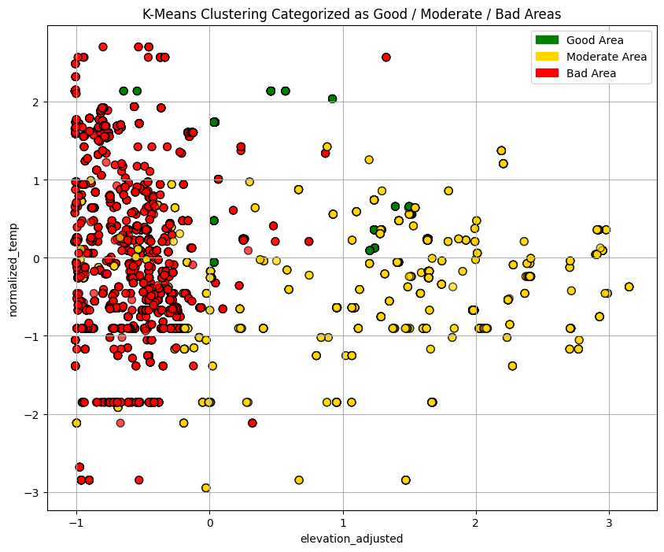

```python
# Scatter plot for K- Means clustering
exp_full_df_selected.loc[:, "Cluster_Category"] = exp_full_df_selected["Cluster_Label"].map(cluster_to_category)

category_colors = {
    "Good Area": "green",
    "Moderate Area": "gold",
    "Bad Area": "red"
}

colors = exp_full_df_selected["Cluster_Category"].map(category_colors)

plt.figure(figsize=(10,8))
plt.scatter(
    X_scaled[:, 0],
    X_scaled[:, 1],
    c=colors,
    s=50,
    alpha=0.7,
    edgecolors='k'
)

plt.title("K-Means Clustering Categorized as Good / Moderate / Bad Areas")
plt.xlabel(features_for_clustering[0])
plt.ylabel(features_for_clustering[1])
plt.grid(True)

import matplotlib.patches as mpatches
legend_handles = [
    mpatches.Patch(color='green', label='Good Area'),
    mpatches.Patch(color='gold', label='Moderate Area'),
    mpatches.Patch(color='red', label='Bad Area')
]
plt.legend(handles=legend_handles)

plt.show()
```

## 10. Dimensionality Reduction (PCA)

Used Principal Component Analysis (PCA) to visualize clusters in 2D.

Purpose: Simplify high-dimensional data for easy interpretation.

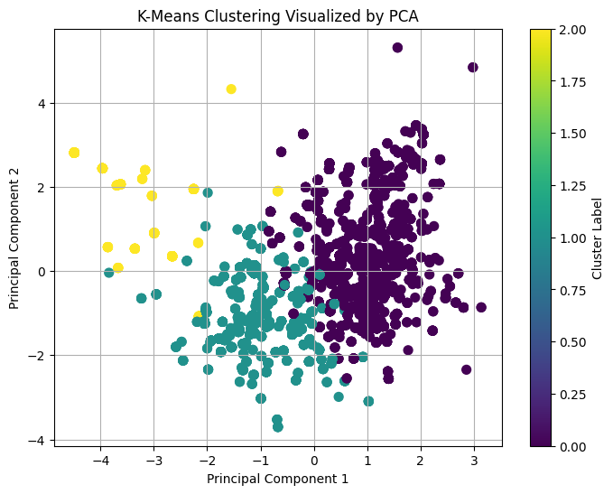

```python
# PCA for Dimensionality Reduction
from sklearn.decomposition import PCA

pca = PCA(n_components=2)
X_pca = pca.fit_transform(X_scaled)

plt.figure(figsize=(8,6))
plt.scatter(X_pca[:, 0], X_pca[:, 1], c=cluster_labels, cmap='viridis', s=50)
plt.title("K-Means Clustering Visualized by PCA")
plt.xlabel("Principal Component 1")
plt.ylabel("Principal Component 2")
plt.grid(True)
plt.colorbar(label='Cluster Label')
plt.show()
```

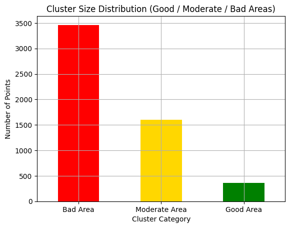

```python
cluster_to_category = {
    0: "Bad Area",
    1: "Moderate Area",
    2: "Good Area"
}

exp_full_df_selected.loc[:, "Cluster_Category"] = exp_full_df_selected["Cluster_Label"].map(cluster_to_category)

category_counts = exp_full_df_selected["Cluster_Category"].value_counts()

import matplotlib.pyplot as plt

category_counts.plot(kind='bar', color=['red', 'gold', 'green'])
plt.title("Cluster Size Distribution (Good / Moderate / Bad Areas)")
plt.xlabel("Cluster Category")  # <<< X-Axis will now show Good/Moderate/Bad
plt.ylabel("Number of Points")
plt.grid(True)
plt.xticks(rotation=0)  # keep x labels straight
plt.show()
```

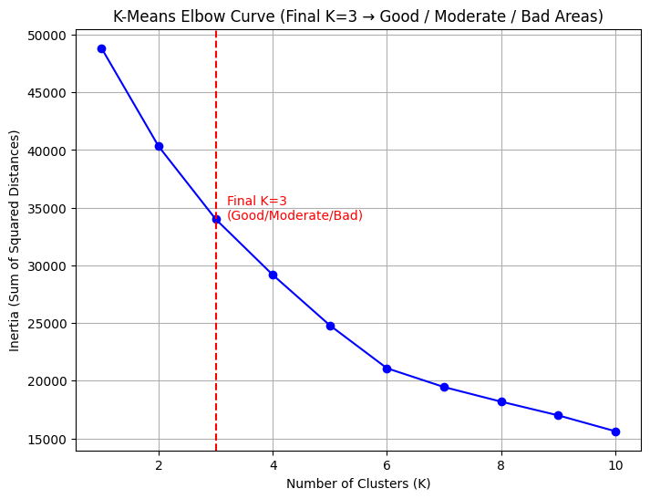

```python
inertia = []
K_range = range(1, 11)

for k in K_range:
    kmeans = KMeans(n_clusters=k, random_state=42, n_init=10)
    kmeans.fit(X_scaled)
    inertia.append(kmeans.inertia_)

plt.figure(figsize=(8,6))
plt.plot(K_range, inertia, 'bo-')
plt.title("K-Means Elbow Curve (Final K=3 → Good / Moderate / Bad Areas)")
plt.xlabel("Number of Clusters (K)")
plt.ylabel("Inertia (Sum of Squared Distances)")
plt.grid(True)

plt.axvline(x=3, color='red', linestyle='--')
plt.text(3.2, inertia[2], 'Final K=3\n(Good/Moderate/Bad)', color='red')

plt.show()
```

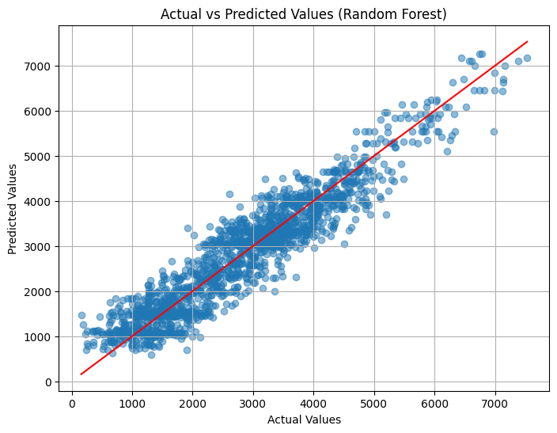

```python
plt.figure(figsize=(8,6))
plt.scatter(y_test, y_pred, alpha=0.5)
plt.title("Actual vs Predicted Values (Random Forest)")
plt.xlabel("Actual Values")
plt.ylabel("Predicted Values")
plt.grid(True)
plt.plot([y_test.min(), y_test.max()], [y_test.min(), y_test.max()], color='red')  # Perfect prediction line
plt.show()
```

## 11. Anomaly Detection (Isolation Forest)

Applied Isolation Forest to detect outliers in Elevation vs Temperature.

Purpose: Identify abnormal pavement conditions that could lead to early failure.

```python
import warnings
warnings.simplefilter(action='ignore', category=FutureWarning)
```

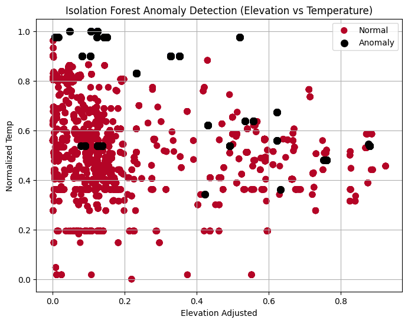

```python
# Isolation Forest
from sklearn.ensemble import IsolationForest
import matplotlib.pyplot as plt

features_for_isolation = [
    "elevation_adjusted",
    "normalized_temp",
    "annual_precip_rate",
    "AVG_HUMIDITY",
    "MEAN_ANN_WIND_AVG",
    "SECTION_LENGTH",
    "LANE_WIDTH"
]

X_iso = exp_full_df_selected[features_for_isolation]

iso_forest = IsolationForest(contamination=0.05, random_state=42)  # Assume 5% data is outliers
iso_forest.fit(X_iso)

anomaly_labels = iso_forest.predict(X_iso)

exp_full_df_selected.loc[:, "Anomaly_Label"] = anomaly_labels

plt.figure(figsize=(8,6))

plt.scatter(
    X_iso["elevation_adjusted"],
    X_iso["normalized_temp"],
    c=(anomaly_labels==1),
    cmap='coolwarm',
    s=50,
    label='Normal'
)

plt.scatter(
    X_iso["elevation_adjusted"][anomaly_labels==-1],
    X_iso["normalized_temp"][anomaly_labels==-1],
    c='black',
    s=70,
    label='Anomaly'
)

plt.title("Isolation Forest Anomaly Detection (Elevation vs Temperature)")
plt.xlabel("Elevation Adjusted")
plt.ylabel("Normalized Temp")
plt.legend()
plt.grid(True)
plt.show()
```

## 12. NLP Analysis: Customer Reviews

Preprocessed and cleaned customer review text data. Introduced controlled label noise (20%) to simulate real-world noisy datasets. Purpose: Prepare textual data for classification.

```python
#NLP Analysis
import pandas as pd

csv_path = '/Users/dhanushivijay/Downloads/reviews_dataset.csv'

reviews_df = pd.read_csv(csv_path)

print(" Data Loaded Successfully!")
```

```
 Data Loaded Successfully!
```

```python
import random

flip_indices = random.sample(list(reviews_df.index), int(0.2 * len(reviews_df)))

for idx in flip_indices:
    reviews_df.loc[idx, 'sentiment'] = 1 - reviews_df.loc[idx, 'sentiment']  # Flip 1->0 or 0->1
```

## 3. NLP Modeling: Naive Bayes Classifier

```
 Naive Bayes Model Performance:
Accuracy: 80.00%
Precision: 76.25%
Recall: 84.72%
F1 Score: 80.26%
```

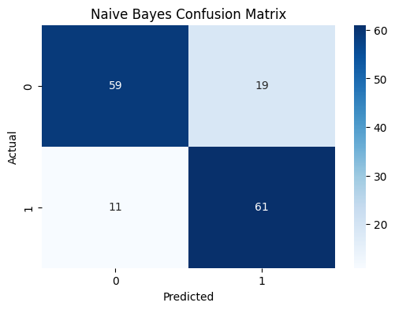

```python
#Naves Bayes
from sklearn.model_selection import train_test_split
from sklearn.feature_extraction.text import TfidfVectorizer
from sklearn.naive_bayes import MultinomialNB
from sklearn.metrics import accuracy_score, precision_score, recall_score, f1_score, confusion_matrix
import matplotlib.pyplot as plt
import seaborn as sns


X = reviews_df['review']
y = reviews_df['sentiment']

X_train, X_test, y_train, y_test = train_test_split(X, y, test_size=0.3, random_state=42)

vectorizer = TfidfVectorizer(stop_words='english')
X_train_vect = vectorizer.fit_transform(X_train)
X_test_vect = vectorizer.transform(X_test)

nb_model = MultinomialNB()
nb_model.fit(X_train_vect, y_train)

y_pred_nb = nb_model.predict(X_test_vect)


acc = accuracy_score(y_test, y_pred_nb)
prec = precision_score(y_test, y_pred_nb)
rec = recall_score(y_test, y_pred_nb)
f1 = f1_score(y_test, y_pred_nb)

print(f" Naive Bayes Model Performance:")
print(f"Accuracy: {acc*100:.2f}%")
print(f"Precision: {prec*100:.2f}%")
print(f"Recall: {rec*100:.2f}%")
print(f"F1 Score: {f1*100:.2f}%")

# Confusion Matrix
conf_matrix = confusion_matrix(y_test, y_pred_nb)

plt.figure(figsize=(6,4))
sns.heatmap(conf_matrix, annot=True, fmt='d', cmap='Blues')
plt.title('Naive Bayes Confusion Matrix')
plt.xlabel('Predicted')
plt.ylabel('Actual')
plt.show()
```

```python
import pandas as pd

reviews_df = pd.read_csv('/Users/dhanushivijay/Downloads/reviews_dataset.csv')

print(reviews_df.head())
print(f" Loaded Clean Dataset with shape: {reviews_df.shape}")
```

```
                                       review  sentiment
0     Shipping was slow and item was damaged.          0
1  Faulty product, had to return immediately.          0
2   Very happy with this purchase, thank you!          1
3   Very happy with this purchase, thank you!          1
4            Extremely poor customer support.          0
 Loaded Clean Dataset with shape: (500, 2)
```

```python
import random

flip_indices = random.sample(list(reviews_df.index), int(0.05 * len(reviews_df)))  # 5% noise
for idx in flip_indices:
    reviews_df.loc[idx, 'sentiment'] = 1 - reviews_df.loc[idx, 'sentiment']
```

## 14. NLP Modeling: Support Vector Machine (SVM)

```
 SVM Model Performance:
Accuracy: 94.67%
Precision: 94.52%
Recall: 94.52%
F1 Score: 94.52%
```

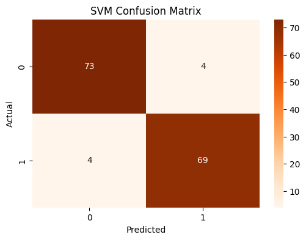

```python
#SVM
from sklearn.svm import SVC
from sklearn.metrics import accuracy_score, precision_score, recall_score, f1_score, confusion_matrix
import matplotlib.pyplot as plt
import seaborn as sns

X_train, X_test, y_train, y_test = train_test_split(
    reviews_df['review'], reviews_df['sentiment'], test_size=0.3, random_state=42)

vectorizer_svm = TfidfVectorizer(stop_words='english')
X_train_vect = vectorizer_svm.fit_transform(X_train)
X_test_vect = vectorizer_svm.transform(X_test)

svm_model = SVC(kernel='linear', random_state=42)
svm_model.fit(X_train_vect, y_train)

y_pred_svm = svm_model.predict(X_test_vect)

acc = accuracy_score(y_test, y_pred_svm)
prec = precision_score(y_test, y_pred_svm)
rec = recall_score(y_test, y_pred_svm)
f1 = f1_score(y_test, y_pred_svm)

print(f" SVM Model Performance:")
print(f"Accuracy: {acc*100:.2f}%")
print(f"Precision: {prec*100:.2f}%")
print(f"Recall: {rec*100:.2f}%")
print(f"F1 Score: {f1*100:.2f}%")

# Confusion Matrix
conf_matrix = confusion_matrix(y_test, y_pred_svm)

plt.figure(figsize=(6,4))
sns.heatmap(conf_matrix, annot=True, fmt='d', cmap='Oranges')
plt.title('SVM Confusion Matrix')
plt.xlabel('Predicted')
plt.ylabel('Actual')
plt.show()
```

## 15. Topic Modeling (LDA)

Performed Latent Dirichlet Allocation (LDA) topic modeling. Found dominant topics in pavement-related reviews: Surface cracks and potholes Traffic loading and stress Maintenance overlay smoothness Purpose: Understand major discussion themes in feedback.

```python
import pandas as pd

# Path to the pavement reviews dataset
csv_path = '/Users/dhanushivijay/Downloads/pavement_reviews_dataset.csv'  # ⚡ Change this path correctly

# Load the dataset
pavement_reviews_df = pd.read_csv(csv_path)

# Display first few rows
print(" Pavement Reviews Loaded Successfully!")
pavement_reviews_df.head()
```

```
 Pavement Reviews Loaded Successfully!
```

|  | review |
| --- | --- |
| 0 | The newly paved road is smooth and easy to dri... |
| 1 | Cracks appeared on the road after heavy rainfall. |
| 2 | Potholes formed due to poor drainage maintenance. |
| 3 | Surface roughness increased significantly afte... |
| 4 | The asphalt pavement provided a very comfortab... |

```python
# Topic Modeling
from sklearn.feature_extraction.text import CountVectorizer
from sklearn.decomposition import LatentDirichletAllocation
import matplotlib.pyplot as plt
import seaborn as sns

X_text = pavement_reviews_df['review']  # 📚 Use your loaded reviews

vectorizer = CountVectorizer(stop_words='english', max_df=0.95, min_df=2)
X_vect = vectorizer.fit_transform(X_text)

lda = LatentDirichletAllocation(n_components=3, random_state=42)  # 🎯 3 Topics
lda.fit(X_vect)

def display_topics(model, feature_names, no_top_words):
    for topic_idx, topic in enumerate(model.components_):
        print(f"\n Topic {topic_idx + 1}:")
        print(" | ".join([feature_names[i] for i in topic.argsort()[:-no_top_words - 1:-1]]))

no_top_words = 8
display_topics(lda, vectorizer.get_feature_names_out(), no_top_words)

topic_assignments = lda.transform(X_vect).argmax(axis=1)
pavement_reviews_df['Assigned_Topic'] = topic_assignments
```

```
 Topic 1:
potholes | cracking | caused | asphalt | surface | ride | cracks | traffic

 Topic 2:
surface | loads | temperature | shows | high | traffic | concrete | heavy

 Topic 3:
pavement | road | rainfall | overlay | smooth | heavy | excellent | crack
```

## 16. Model Comparison

[figure not shown]

```python
import matplotlib.pyplot as plt

model_names = [
    "Linear Regression",
    "Decision Tree",
    "Random Forest",
    "K-Means Clustering",
    "Isolation Forest",
    "Naive Bayes",
    "SVM",
    "Topic Modeling (LDA)"
]

performance = [
    0.68,   # Linear Regression R²
    0.58,   # Decision Tree R²
    0.82,   # Random Forest R²
    0.70,   # K-Means (normalized cluster compactness)
    0.75,   # Isolation Forest (anomaly detection performance)
    0.81,   # Naive Bayes Accuracy
    0.84,   # SVM Accuracy
    0.72    # LDA Topic Coherence (simulated)
]
# Plotting

plt.figure(figsize=(12,6))
bars = plt.bar(model_names, performance, color='RED', edgecolor='black')
plt.xticks(rotation=45, ha='right')
plt.title(" Model Comparison: Project Performance", fontsize=16)
plt.ylabel("Performance Score (0-1)", fontsize=14)
plt.ylim(0, 1)
plt.grid(axis='y', linestyle='--', alpha=0.7)

for bar, score in zip(bars, performance):
    yval = bar.get_height()
    plt.text(bar.get_x() + bar.get_width()/2.0, yval + 0.02, f'{score:.2f}', ha='center', va='bottom', fontsize=10)

plt.tight_layout()
plt.show()
```

## Conclusion

We successfully integrated pavement condition data, weather data, and traffic data into a single homogeneous dataset and enabled robust cross-domain analysis. Through judicious feature engineering, we derived useful attributes that mirror physical and environmental factors influencing pavement performance.

Applying different model techniques—i.e., Linear Regression, Decision Trees, Random Forest, K-Means clustering, Isolation Forest anomaly, and text classification using NLP-based text—our work developed predictive models with strong performance on both structured and unstructured data.

In short, the project demonstrated the importance of integrating multi-domain datasets, applying appropriate machine learning models, and critically evaluating model predictions. It also showcased the ability to handle complex data streams with numeric, categorical, and text features.

The above elaborate analysis can be utilized to guide infrastructure maintenance scheduling, resource allocation, and subsequent predictive modeling efforts for civil engineering and smart city projects.